# CDS scRNA-seq Workshop 2022 Section 2 - Subtyping and Pathway Analysis

Stephanie The

2022-04-06

# Packages

**If you are starting a new session, you will need to reload the packages and run the code below:**

```r
library(tidyverse)
library(Seurat)
library(pheatmap)
library(RColorBrewer)
library(scales)
library(cowplot)
library(patchwork)
library(grid)
library(gridExtra)
library(harmony)
library(clusterProfiler)
library(org.Hs.eg.db)
library(ReactomePA)
library(msigdbr)
```

```r
# set seed
set.seed(1383)

# set working directory
setwd('D:/scRNA-seq pipeline/pasca_dataset/')

# load annotated object
merged_ob <- readRDS('cds_pasca_example_umap_harmony_annote_1.rds')
```

# Subtyping Analysis

Earlier we gave very broad, general labels to the clusters, but from looking at the article, we see that there are a lot of subtypes for some of the cell types, such as myeloid, T, and fibroblasts. With subtyping analysis, we can look at these cell types in further detail.

We will first be doing this with the fibroblasts as an example.

## Subset population

We first subset any cell with the label ‘fibroblast’ and make a new object with only fibroblasts. We can do this with the code below:

```r
fb <- subset(merged_ob, subset = annote_1 == 'fibroblast')
```

We will then run the main pipeline again on the subsetted object from normalization to cell annotation. We have to do this because we are now looking at subset of cells instead of the whole dataset. We will also integrate with Harmony like we did before because the batch effect will still be present in the raw counts.

## Main Pipeline

### Normalization

```r
fb <- NormalizeData(fb, verbose = F)
```

### Find Variable Features

```r
fb <- FindVariableFeatures(fb, selection.method = 'vst', nfeatures = 2000, verbose = F)
```

### Scaling

```r
fb <- ScaleData(fb, vars.to.regress = 'nCount_RNA', verbose = F)
```

### PCA

```r
fb <- RunPCA(object = fb, features = VariableFeatures(fb),
                nfeatures.print = 5, verbose = F)
```

```r
# qualitative
# ElbowPlot(object = fb, ndims = 50)

# quantitative
pct <- fb@reductions$pca@stdev / sum(fb@reductions$pca@stdev) * 100
cum <- cumsum(pct)
co1 <- which(cum > 90 & pct < 5)[1]
co2 <- sort(which((pct[1:length(pct)-1] - pct[2:length(pct)]) > .1), decreasing = T)[1] + 1
pcs <- min(co1, co2) # 14 pcs

# DimPlot(fb, reduction = 'pca', group.by = 'sample_id')
```

### Integration (w/ Harmony)

```r
fb <- RunHarmony(fb, group.by.vars = c('sample_id'), dims.use = 1:pcs, verbose = F)
```

### Clustering

```r
fb <- FindNeighbors(fb, dims = 1:pcs, k.param = 20, reduction = 'harmony', verbose = F)
fb <- FindClusters(fb, verbose = F)
head(Idents(fb), 5)
```

```
## AdjNorm_TISSUE_1_AAACCCAGTCCGACGT-1 AdjNorm_TISSUE_1_AAACGAATCACTGAAC-1
##                                   7                                   0
## AdjNorm_TISSUE_1_AAAGAACAGACGCATG-1 AdjNorm_TISSUE_1_AAAGAACGTTCAAGTC-1
##                                   3                                   1
## AdjNorm_TISSUE_1_AAAGGATAGGGTGAAA-1
##                                   7
## Levels: 0 1 2 3 4 5 6 7 8 9
```

```r
# store clusters in other metadata slot
fb$harmony_clusters <- Idents(fb)
```

### UMAP

```r
fb <- RunUMAP(fb, dims = 1:pcs, reduction = 'harmony', reduction.name = 'umap_harmony', verbose = F)
```

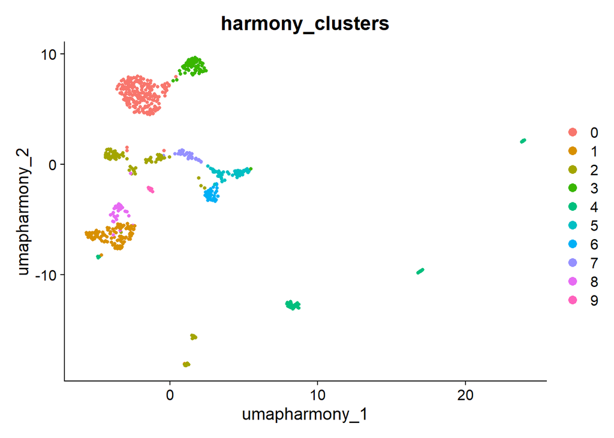

```r
DimPlot(fb, group.by = 'harmony_clusters', reduction = 'umap_harmony')
```

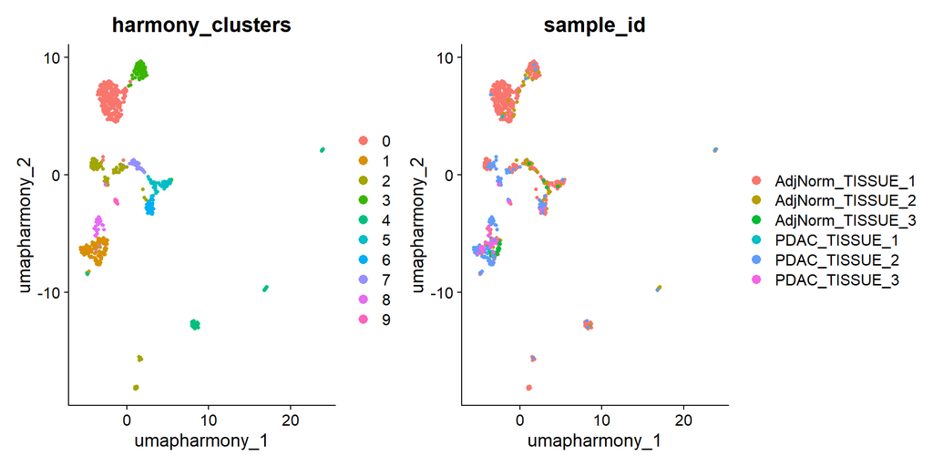

```r
DimPlot(fb, group.by = c('harmony_clusters', 'sample_id'), reduction = 'umap_harmony')
```

### Cell Annotation

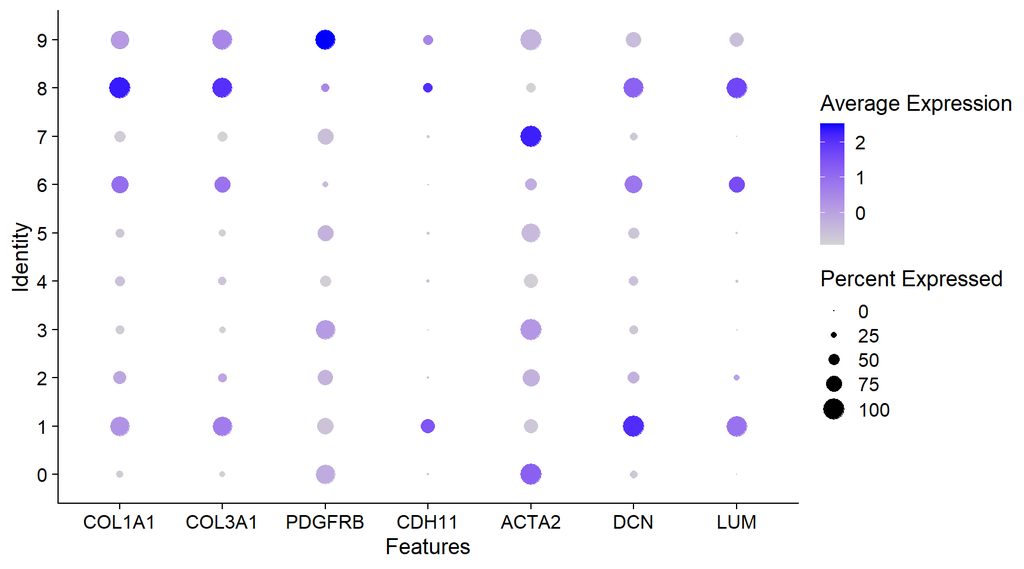

```r
# look at fibroblast gene markers
DotPlot(fb, features = c('COL1A1','COL3A1','PDGFRB','CDH11','ACTA2','DCN','LUM'))
```

- 0 = myCAF
- 1 = iCAF
- 2 = fibroblast
- 3 = myCAF
- 4 = fibroblast
- 5 = fibroblast
- 6 = iCAF
- 7 = myCAF
- 8 = iCAF
- 9 = iCAF

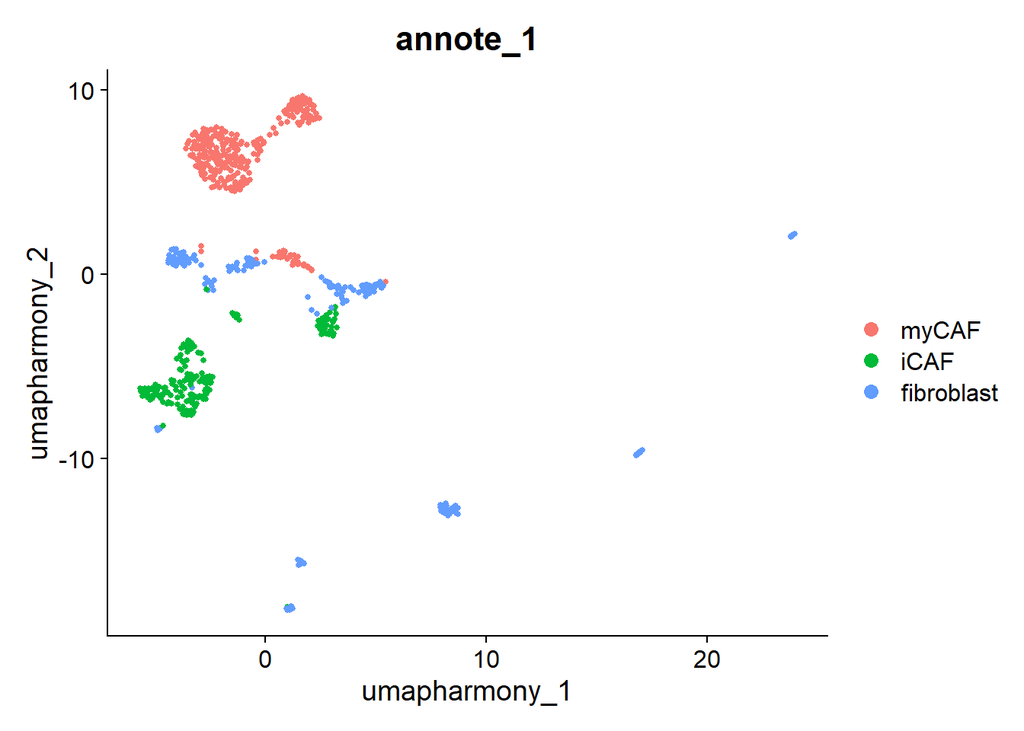

```r
# add new labels to object
new_clusters <- c('myCAF','iCAF','fibroblast','myCAF','fibroblast','fibroblast','iCAF','myCAF','iCAF','iCAF')
names(new_clusters) <- 0:9
fb <- RenameIdents(fb, new_clusters)
fb$annote_1 <- Idents(fb)

DimPlot(fb, reduction = 'umap_harmony', group.by = 'annote_1')
```

### Save Fibroblast Object

```r
saveRDS(fb, file = 'cds_pasca_example_fibro_umap_harmony_annote_1_032922.rds')
```

## Transfering Labels

After annotating our new fibroblast clusters, we can transfer the labels to the whole dataset if we wanted to. We can do this with the code below:

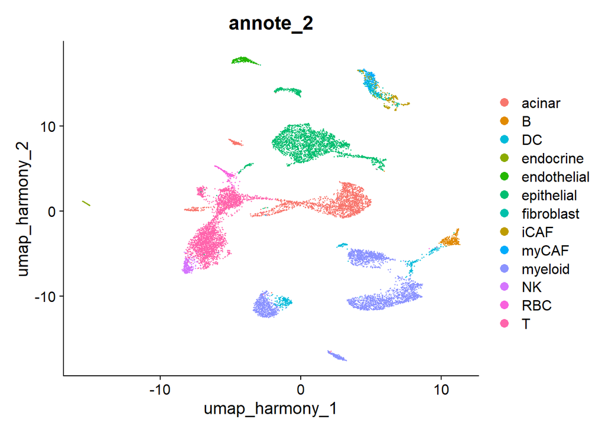

```r
# get the new fibroblast labels from the fibroblast object
x <- FetchData(fb, vars = c('annote_1'))

# find the cell names that were originally called 'fibroblast'
y <- WhichCells(merged_ob, expression = annote_1 == 'fibroblast')

# order the cells from the fibroblast object so they are in the same order in the whole dataset
x <- x[y,,drop=F]

# create a new annotation column in the metadata slot
merged_ob$annote_2 <- as.character(merged_ob$annote_1)

# add the new fibroblast labels to the new annotation column
merged_ob$annote_2[y] <- as.character(x$annote_1)

# plot UMAP with new labels
colors <- scales::hue_pal()(13)
colors <- c(colors[1:2],colors[8],colors[4:7], colors[3],colors[9:13])
DimPlot(merged_ob, reduction = 'umap_harmony', group.by = 'annote_2') + scale_colour_manual(values = colors)
```

## Exercise: Myeloid Subtyping Analysis

Now that we have an idea of how to subtype, I would like you to subtype the myeloid cell population. Start by subsetting the cells with the label ‘myeloid’, and then run the main pipeline on this new subsetted object.

When you get to the cell annotation part, please use this vector of myeloid gene markers (copy and paste in code when needed).

```
c('CD14','HLA-DRA','ITGAX','ITGAM','APOE','LYZ','CLU','CPA3','TPSAB1')
```

### Answer

```r
# main pipeline
myeloid <- subset(merged_ob, subset = annote_1 == 'myeloid')
myeloid <- NormalizeData(myeloid, verbose = F)

myeloid <- FindVariableFeatures(myeloid, selection.method = 'vst', nfeatures = 2000, verbose = F)

myeloid <- ScaleData(myeloid, vars.to.regress = 'nCount_RNA', verbose = F)

myeloid <- RunPCA(object = myeloid, features = VariableFeatures(myeloid),
                nfeatures.print = 5, verbose = F)
pct <- myeloid@reductions$pca@stdev / sum(myeloid@reductions$pca@stdev) * 100
cum <- cumsum(pct)
co1 <- which(cum > 90 & pct < 5)[1]
co2 <- sort(which((pct[1:length(pct)-1] - pct[2:length(pct)]) > .1), decreasing = T)[1] + 1
pcs <- min(co1, co2) # 13 pcs

myeloid <- RunHarmony(myeloid, group.by.vars = c('sample_id'), dims.use = 1:pcs, verbose = F)
myeloid <- FindNeighbors(myeloid, dims = 1:pcs, k.param = 20, reduction = 'harmony', verbose = F)
myeloid <- FindClusters(myeloid, verbose = F)
myeloid$harmony_clusters <- Idents(myeloid)

myeloid <- RunUMAP(myeloid, dims = 1:pcs, reduction = 'harmony', reduction.name = 'umap_harmony', verbose = F)
```

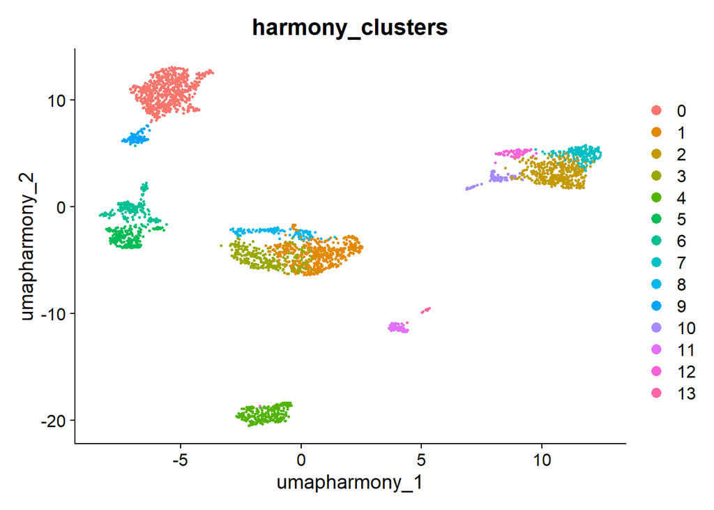

```r
DimPlot(myeloid, group.by = 'harmony_clusters', reduction = 'umap_harmony')
```

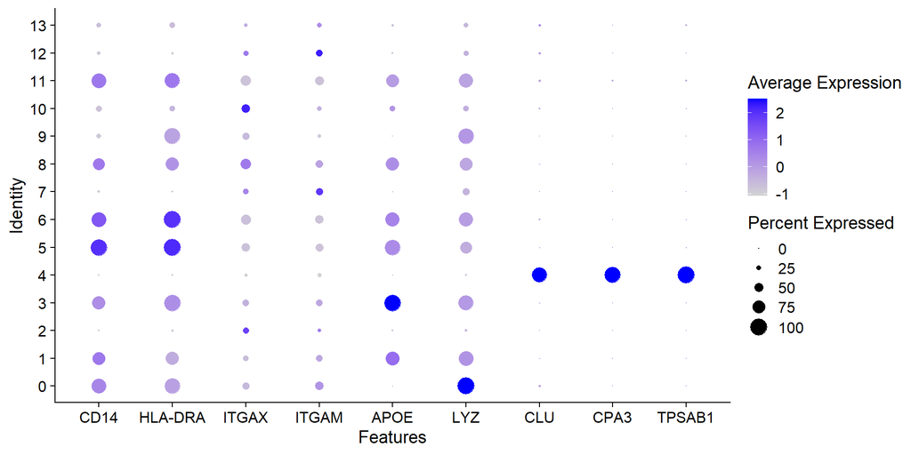

```r
# cell annotation
DotPlot(myeloid, features = c('CD14','HLA-DRA','ITGAX','ITGAM','APOE','LYZ','CLU','CPA3','TPSAB1'))
```

Annotations:

- 0 = macrophage
- 1 = macrophage
- 2 = granulocyte
- 3 = macrophage
- 4 = mast
- 5 = macrophage
- 6 = macrophage
- 7 = granulocyte
- 8 = macrophage
- 9 = myeloid
- 10 = granulocyte
- 11 = macrophage
- 12 = granulocyte
- 13 = myeloid

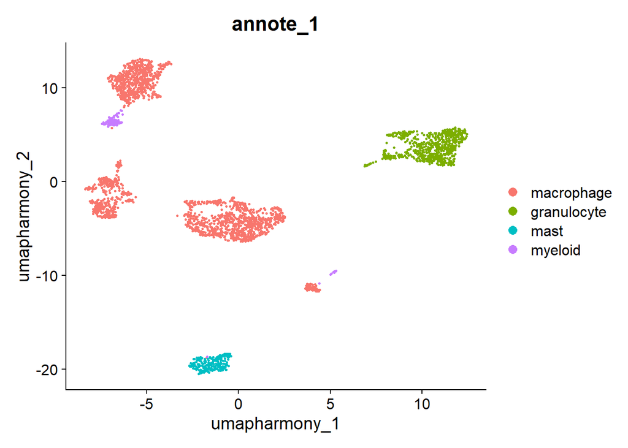

```r
new_clusters <- c('macrophage','macrophage','granulocyte','macrophage','mast','macrophage','macrophage','granulocyte', 'macrophage','myeloid', 'granulocyte','macrophage','granulocyte','myeloid')
names(new_clusters) <- 0:13
myeloid <- RenameIdents(myeloid, new_clusters)
myeloid$annote_1 <- Idents(myeloid)

DimPlot(myeloid, reduction = 'umap_harmony', group.by = 'annote_1')
```

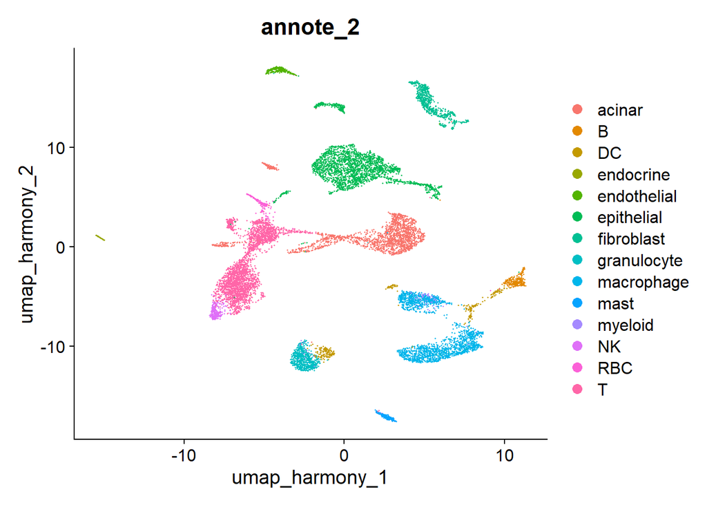

```r
# transfer myeloid labels to whole dataset
# get the new myeloid labels from the myeloid object
x <- FetchData(myeloid, vars = c('annote_1'))
y <- WhichCells(merged_ob, expression = annote_1 == 'myeloid')
x <- x[y,,drop=F]

# create a new annotation column in the metadata slot
merged_ob$annote_2 <- as.character(merged_ob$annote_1)

# add the new fibroblast labels to the new annotation column
merged_ob$annote_2[y] <- as.character(x$annote_1)

# plot UMAP with new labels
DimPlot(merged_ob, reduction = 'umap_harmony', group.by = 'annote_2')
```

# Pathway Analysis

Pathway analysis is a way to analyze groups of related genes between conditions. This helps to interpret large gene lists into biological conditions. There are three types of pathway analyses:

1. Over-representation analysis (ORA)
2. Functional class scoring (FCS)
3. Pathway-topology based (PTB)

For this workshop, we will only be learning how to run ORA and FCS (which we’ll use GSEA). We will be using the clusterProfiler package to run these two analyses. You can look at the manual for more functions:

- http://yulab-smu.top/clusterProfiler-book/

**Before we can actually run analyses, we need to prepare some data.**

We first refresh our object (from changes from subtyping) to look at the cell type labels from the *‘annote_1’* column from the metadata slot.

```r
# import object and make sure active identity is 'annote_1'
Idents(merged_ob) <- 'annote_1'
levels(merged_ob)
```

```
##  [1] "T"           "acinar"      "epithelial"  "myeloid"     "fibroblast"
##  [6] "B"           "NK"          "endothelial" "DC"          "RBC"
## [11] "endocrine"
```

We will then run DE on cells from a specific cell type between the conditions (N vs. P). We will be running DE on the myeloid cells for this example.

Based on this comparison:

- positive (+) FC = expressed higher in N
- negative (-) FC = expressed lower in N

```r
# run DE between N vs. P conditions for myeloid cells
de <- FindMarkers(merged_ob, ident.1 = 'N', ident.2 = 'P', group.by = 'condition', subset.ident = 'myeloid')
de_filt <- de %>% rownames_to_column('gene') %>% dplyr::filter(p_val_adj < .05) %>% arrange(-avg_log2FC)
```

We will then calculate log2 fold changes between the condition (N vs. P) for myeloid cells. This will output a table of fold changes for all genes found in the object. These fold changes will mainly be used with GSEA.

```r
# calculate log2 fold changes for all genes
## mainly used for GSEA
# ?FoldChange
fc <- FoldChange(merged_ob, ident.1 = 'N', ident.2 = 'P', group.by = 'condition', subset.ident = 'myeloid')
fc <- fc %>% rownames_to_column('gene')
```

We will then convert gene names to IDs from certain databases (Ensembl, Entrez, ALIAS, etc.). We will be converting gene symbols to Entrez IDs. You could also use gene aliases, but it will give you multiple names for the same gene. Also, make sure you are using the correct species. In this example, we will use the human databases.

```r
# key names for the different IDs
keytypes(org.Hs.eg.db)
```

```
##  [1] "ACCNUM"       "ALIAS"        "ENSEMBL"      "ENSEMBLPROT"  "ENSEMBLTRANS"
##  [6] "ENTREZID"     "ENZYME"       "EVIDENCE"     "EVIDENCEALL"  "GENENAME"
## [11] "GENETYPE"     "GO"           "GOALL"        "IPI"          "MAP"
## [16] "OMIM"         "ONTOLOGY"     "ONTOLOGYALL"  "PATH"         "PFAM"
## [21] "PMID"         "PROSITE"      "REFSEQ"       "SYMBOL"       "UCSCKG"
## [26] "UNIPROT"
```

```r
# get Entrez ID for all genes
# ?bitr
bitr_df <- bitr(fc$gene, fromType = 'SYMBOL', toType = 'ENTREZID', OrgDb = org.Hs.eg.db)
# add Entrez IDs to fold change and DE tables
fc$entrezid <- bitr_df$ENTREZID[match(fc$gene, bitr_df$SYMBOL)]
de_filt$entrezid <- bitr_df$ENTREZID[match(de_filt$gene, bitr_df$SYMBOL)]
```

## ORA

With ORA, we can find potentially important pathways through the proportion of genes present in certain pathways. We can run ORA on multiple pathway databases, such as GO, KEGG, Reactome, MSigDB, etc. For this example, we will be running the myeloid cells on the GO terms and MSigDB.

The first step is to choose genes that are potentially important. We will use the DE table to find these genes. We will pick the DE genes that are significant between our conditions (adjusted p-value < .05) and have an avg_log2FC >= 1 or <= -1. Picking these thresholds can be subjective, so you can change the p-value or avg_log2FC or create a score based on these two variables. You will need to make two lists: one for upregulated genes (FC >= 1) and another for downregulated genes (FC <= -1).

```r
# get upregulated genes
or_genes_up <- de_filt$entrezid[de_filt$avg_log2FC >= 1 & !is.na(de_filt$entrezid)]
head(or_genes_up)
```

```
## [1] "5644" "1208" "5406" "3043" "1504" "1357"
```

```r
# get downregulated genes
or_genes_down <- de_filt$entrezid[de_filt$avg_log2FC <= -1 & !is.na(de_filt$entrezid)]
head(or_genes_down)
```

```
## [1] "64859" "2919"  "3434"  "7503"  "91543" "6648"
```

After getting the genes, we can run pathway analysis. We are going to run the upregulated and downregulated separately on GO terms first.

```r
# run analysis on GO
# ?enrichGO

## upregulated pathways
or_go_up <- enrichGO(gene = or_genes_up, universe = bitr_df$ENTREZID, OrgDb = org.Hs.eg.db, ont = 'BP', pAdjustMethod = 'BH', pvalueCutoff = 1, qvalueCutoff = 1, readable = T)
head(or_go_up@result)
```

```
##                    ID                             Description GeneRatio
## GO:0007586 GO:0007586                               digestion      8/34
## GO:0098883 GO:0098883                         synapse pruning      3/34
## GO:0006959 GO:0006959                 humoral immune response      6/34
## GO:0016064 GO:0016064 immunoglobulin mediated immune response      5/34
## GO:0019724 GO:0019724                B cell mediated immunity      5/34
## GO:0150146 GO:0150146               cell junction disassembly      3/34
##              BgRatio       pvalue     p.adjust       qvalue
## GO:0007586 118/14318 2.541957e-10 1.484503e-07 1.281682e-07
## GO:0098883  11/14318 1.992619e-06 5.818447e-04 5.023497e-04
## GO:0006959 186/14318 4.406155e-06 8.577315e-04 7.405433e-04
## GO:0016064 125/14318 1.063150e-05 1.393692e-03 1.203278e-03
## GO:0019724 128/14318 1.193230e-05 1.393692e-03 1.203278e-03
## GO:0150146  21/14318 1.580291e-05 1.538150e-03 1.327999e-03
##                                                  geneID Count
## GO:0007586 PRSS1/CLPS/PNLIP/CTRB1/AMY2A/CTRB2/CEL/PRSS3     8
## GO:0098883                               C1QB/C1QC/C1QA     3
## GO:0006959           PLA2G1B/C1QB/REG1A/PRSS3/C1QC/C1QA     6
## GO:0016064             C1QB/C1QC/C1QA/HLA-DPB1/HLA-DPA1     5
## GO:0019724             C1QB/C1QC/C1QA/HLA-DPB1/HLA-DPA1     5
## GO:0150146                               C1QB/C1QC/C1QA     3
```

```r
## downregulated pathways
or_go_down <- enrichGO(gene = or_genes_down, universe = bitr_df$ENTREZID, OrgDb = org.Hs.eg.db, ont = 'BP', pAdjustMethod = 'BH', pvalueCutoff = 1, qvalueCutoff = 1, readable = T)
head(or_go_down@result)
```

```
##                    ID                                     Description GeneRatio
## GO:0009615 GO:0009615                               response to virus      9/25
## GO:0051607 GO:0051607                       defense response to virus      8/25
## GO:0140546 GO:0140546                    defense response to symbiont      8/25
## GO:0048525 GO:0048525            negative regulation of viral process      6/25
## GO:0045071 GO:0045071 negative regulation of viral genome replication      5/25
## GO:0019079 GO:0019079                        viral genome replication      6/25
##              BgRatio       pvalue     p.adjust       qvalue
## GO:0009615 316/14318 1.660829e-09 1.096788e-06 7.683556e-07
## GO:0051607 225/14318 2.821925e-09 1.096788e-06 7.683556e-07
## GO:0140546 225/14318 2.821925e-09 1.096788e-06 7.683556e-07
## GO:0048525  83/14318 5.122007e-09 1.493065e-06 1.045968e-06
## GO:0045071  50/14318 2.131625e-08 4.970951e-06 3.482403e-06
## GO:0019079 117/14318 4.082481e-08 7.933621e-06 5.557904e-06
##                                                     geneID Count
## GO:0009615 IFIT1/RSAD2/LYST/TNF/MX1/IFIT2/IFIT3/ISG15/IFI6     9
## GO:0051607     IFIT1/RSAD2/LYST/MX1/IFIT2/IFIT3/ISG15/IFI6     8
## GO:0140546     IFIT1/RSAD2/LYST/MX1/IFIT2/IFIT3/ISG15/IFI6     8
## GO:0048525                  IFIT1/RSAD2/TNF/MX1/LY6E/ISG15     6
## GO:0045071                       IFIT1/RSAD2/TNF/MX1/ISG15     5
## GO:0019079                  IFIT1/RSAD2/TNF/CCL2/MX1/ISG15     6
```

I usually set the *‘pvalueCutoff’* and *‘qvalueCutoff’* parameters to get all the pathways (significant and not significant).

We are going to run the upregulated and downregulated separately on the hallmark pathways in MSigDB next.

```r
# get genes in hallmark pathways from MSigDB
## get gene symbols and Entrez IDs
# ?msigdbr
m_df <- msigdbr(species = 'Homo sapiens', category = 'H') %>% dplyr::select(gs_name, entrez_gene)

# run analysis on hallmark pathways
## upregulated pathways
or_msigdb_h_up <- enricher(or_genes_up, TERM2GENE = m_df, universe = bitr_df$ENTREZID, pAdjustMethod = 'BH', pvalueCutoff = 1, qvalueCutoff = 1)
### replace entrez ids with gene symbols
or_msigdb_h_up@result$geneID <- sapply(or_msigdb_h_up@result$geneID, function(i) {
      y <- strsplit(i,'/')[[1]]
      y <- bitr_df$SYMBOL[match(y,bitr_df$ENTREZID)]
      paste(y, collapse = '/')
    })
head(or_msigdb_h_up@result)
```

```
##                                                                ID
## HALLMARK_KRAS_SIGNALING_DN             HALLMARK_KRAS_SIGNALING_DN
## HALLMARK_COMPLEMENT                           HALLMARK_COMPLEMENT
## HALLMARK_IL6_JAK_STAT3_SIGNALING HALLMARK_IL6_JAK_STAT3_SIGNALING
## HALLMARK_INFLAMMATORY_RESPONSE     HALLMARK_INFLAMMATORY_RESPONSE
## HALLMARK_ESTROGEN_RESPONSE_EARLY HALLMARK_ESTROGEN_RESPONSE_EARLY
## HALLMARK_ESTROGEN_RESPONSE_LATE   HALLMARK_ESTROGEN_RESPONSE_LATE
##                                                       Description GeneRatio
## HALLMARK_KRAS_SIGNALING_DN             HALLMARK_KRAS_SIGNALING_DN      4/17
## HALLMARK_COMPLEMENT                           HALLMARK_COMPLEMENT      3/17
## HALLMARK_IL6_JAK_STAT3_SIGNALING HALLMARK_IL6_JAK_STAT3_SIGNALING      2/17
## HALLMARK_INFLAMMATORY_RESPONSE     HALLMARK_INFLAMMATORY_RESPONSE      2/17
## HALLMARK_ESTROGEN_RESPONSE_EARLY HALLMARK_ESTROGEN_RESPONSE_EARLY      2/17
## HALLMARK_ESTROGEN_RESPONSE_LATE   HALLMARK_ESTROGEN_RESPONSE_LATE      2/17
##                                   BgRatio      pvalue  p.adjust    qvalue
## HALLMARK_KRAS_SIGNALING_DN       171/4136 0.004399056 0.1011783 0.0926117
## HALLMARK_COMPLEMENT              197/4136 0.044186471 0.3640293 0.3332076
## HALLMARK_IL6_JAK_STAT3_SIGNALING  86/4136 0.047482077 0.3640293 0.3332076
## HALLMARK_INFLAMMATORY_RESPONSE   192/4136 0.185221615 0.5645117 0.5167155
## HALLMARK_ESTROGEN_RESPONSE_EARLY 193/4136 0.186721724 0.5645117 0.5167155
## HALLMARK_ESTROGEN_RESPONSE_LATE  194/4136 0.188223911 0.5645117 0.5167155
##                                              geneID Count
## HALLMARK_KRAS_SIGNALING_DN       CLPS/CPB1/GP2/CPA2     4
## HALLMARK_COMPLEMENT                 PRSS3/C1QC/C1QA     3
## HALLMARK_IL6_JAK_STAT3_SIGNALING        REG1A/IL1R2     2
## HALLMARK_INFLAMMATORY_RESPONSE            CD69/RGS1     2
## HALLMARK_ESTROGEN_RESPONSE_EARLY         AREG/FKBP5     2
## HALLMARK_ESTROGEN_RESPONSE_LATE          AREG/FKBP5     2
```

```r
## downregulated pathways
or_msigdb_h_down <- enricher(or_genes_down, TERM2GENE = m_df, universe = bitr_df$ENTREZID, pAdjustMethod = 'BH', pvalueCutoff = 1, qvalueCutoff = 1)
### replace entrez ids with gene symbols
or_msigdb_h_down@result$geneID <- sapply(or_msigdb_h_down@result$geneID, function(i) {
      y <- strsplit(i,'/')[[1]]
      y <- bitr_df$SYMBOL[match(y,bitr_df$ENTREZID)]
      paste(y, collapse = '/')
    })
head(or_msigdb_h_down@result)
```

```
##                                                                    ID
## HALLMARK_INTERFERON_GAMMA_RESPONSE HALLMARK_INTERFERON_GAMMA_RESPONSE
## HALLMARK_INTERFERON_ALPHA_RESPONSE HALLMARK_INTERFERON_ALPHA_RESPONSE
## HALLMARK_TNFA_SIGNALING_VIA_NFKB     HALLMARK_TNFA_SIGNALING_VIA_NFKB
## HALLMARK_UNFOLDED_PROTEIN_RESPONSE HALLMARK_UNFOLDED_PROTEIN_RESPONSE
## HALLMARK_IL6_JAK_STAT3_SIGNALING     HALLMARK_IL6_JAK_STAT3_SIGNALING
## HALLMARK_FATTY_ACID_METABOLISM         HALLMARK_FATTY_ACID_METABOLISM
##                                                           Description GeneRatio
## HALLMARK_INTERFERON_GAMMA_RESPONSE HALLMARK_INTERFERON_GAMMA_RESPONSE     11/18
## HALLMARK_INTERFERON_ALPHA_RESPONSE HALLMARK_INTERFERON_ALPHA_RESPONSE      7/18
## HALLMARK_TNFA_SIGNALING_VIA_NFKB     HALLMARK_TNFA_SIGNALING_VIA_NFKB      6/18
## HALLMARK_UNFOLDED_PROTEIN_RESPONSE HALLMARK_UNFOLDED_PROTEIN_RESPONSE      3/18
## HALLMARK_IL6_JAK_STAT3_SIGNALING     HALLMARK_IL6_JAK_STAT3_SIGNALING      2/18
## HALLMARK_FATTY_ACID_METABOLISM         HALLMARK_FATTY_ACID_METABOLISM      2/18
##                                     BgRatio       pvalue     p.adjust
## HALLMARK_INTERFERON_GAMMA_RESPONSE 197/4136 5.170351e-11 1.085774e-09
## HALLMARK_INTERFERON_ALPHA_RESPONSE  95/4136 6.995273e-08 7.345037e-07
## HALLMARK_TNFA_SIGNALING_VIA_NFKB   197/4136 1.242186e-04 8.695305e-04
## HALLMARK_UNFOLDED_PROTEIN_RESPONSE 107/4136 1.035155e-02 5.434566e-02
## HALLMARK_IL6_JAK_STAT3_SIGNALING    86/4136 5.271086e-02 2.213856e-01
## HALLMARK_FATTY_ACID_METABOLISM     152/4136 1.400153e-01 3.108028e-01
##                                          qvalue
## HALLMARK_INTERFERON_GAMMA_RESPONSE 9.252207e-10
## HALLMARK_INTERFERON_ALPHA_RESPONSE 6.258928e-07
## HALLMARK_TNFA_SIGNALING_VIA_NFKB   7.409533e-04
## HALLMARK_UNFOLDED_PROTEIN_RESPONSE 4.630958e-02
## HALLMARK_IL6_JAK_STAT3_SIGNALING   1.886494e-01
## HALLMARK_FATTY_ACID_METABOLISM     2.648445e-01
##                                                                                            geneID
## HALLMARK_INTERFERON_GAMMA_RESPONSE IFIT1/RSAD2/SOD2/RNF213/CCL2/MX1/PARP14/IFIT2/LY6E/IFIT3/ISG15
## HALLMARK_INTERFERON_ALPHA_RESPONSE                        RSAD2/MX1/PARP14/IFIT2/LY6E/IFIT3/ISG15
## HALLMARK_TNFA_SIGNALING_VIA_NFKB                                  CXCL1/SOD2/CXCL2/TNF/CCL2/IFIT2
## HALLMARK_UNFOLDED_PROTEIN_RESPONSE                                               NABP1/IFIT1/CCL2
## HALLMARK_IL6_JAK_STAT3_SIGNALING                                                        CXCL1/TNF
## HALLMARK_FATTY_ACID_METABOLISM                                                           XIST/MIF
##                                    Count
## HALLMARK_INTERFERON_GAMMA_RESPONSE    11
## HALLMARK_INTERFERON_ALPHA_RESPONSE     7
## HALLMARK_TNFA_SIGNALING_VIA_NFKB       6
## HALLMARK_UNFOLDED_PROTEIN_RESPONSE     3
## HALLMARK_IL6_JAK_STAT3_SIGNALING       2
## HALLMARK_FATTY_ACID_METABOLISM         2
```

There are also functions in clusterProfiler to run KEGG (*enrichKEGG()*), Reactome (*enrichPathway()*; need the ReactomePA package), etc. For MSigDB, we can also run on other categories (ex: C1, C2, C3, etc.), which you can change with the *msigdbr()* function.

## GSEA

GSEA is a type of FCS pathway analysis, which it uses gene expression unlike ORA. We can run GSEA on multiple pathway databases, such as GO, KEGG, Reactome, MSigDB, etc. For this example, we will be running the myeloid cells on the GO terms and MSigDB.

The first step is setup the gene list. In GSEA, we want to use all the genes that change in expression between condition (abs(expression) > 0). We could change what we consider as expressed (ex: abs(expression) > 0.5). We also need to order the gene list so that the genes go from most positive FC to the most negative FC. We could use p-values or some other score to order the genes instead if wanted.

```r
# get FCs and order the gene list
gene_list <- fc %>% arrange(-avg_log2FC) %>% filter(abs(avg_log2FC) > 0) %>% dplyr::select(entrezid,avg_log2FC) %>% tibble::deframe()
head(gene_list)
```

```
##     5644     1208     5406     3043     1504     1357
## 4.746314 4.121349 3.675111 3.421446 3.282634 3.056990
```

We can then run GSEA. We will run the myeloid cells on GO terms first.

```r
# run GSEA on GO terms
# ?gseGO
gsea_go <- gseGO(gene_list, keyType = 'ENTREZID', OrgDb = org.Hs.eg.db, ont = 'BP', pAdjustMethod = 'BH', pvalueCutoff = 1)
```

```
## preparing geneSet collections...
```

```
## GSEA analysis...
```

```
## leading edge analysis...
```

```
## done...
```

```r
## replace entrez ids with gene symbols
gsea_go@result$core_enrichment <- sapply(gsea_go@result$core_enrichment, function(i) {
      y <- strsplit(i,'/')[[1]]
      y <- bitr_df$SYMBOL[match(y,bitr_df$ENTREZID)]
      paste(y, collapse = '/')
    })
head(gsea_go@result)
```

```
##                    ID                  Description setSize enrichmentScore
## GO:0002181 GO:0002181      cytoplasmic translation     142       0.8564088
## GO:0051607 GO:0051607    defense response to virus     217      -0.6821942
## GO:0140546 GO:0140546 defense response to symbiont     217      -0.6821942
## GO:0042254 GO:0042254          ribosome biogenesis     272       0.6425276
## GO:0009615 GO:0009615            response to virus     305      -0.6245056
## GO:0006364 GO:0006364              rRNA processing     207       0.6426669
##                  NES       pvalue     p.adjust      qvalues rank
## GO:0002181  2.416636 1.000000e-10 5.802000e-07 5.257895e-07  811
## GO:0051607 -1.746805 5.740824e-09 1.047478e-05 9.492469e-06 2792
## GO:0140546 -1.746805 5.740824e-09 1.047478e-05 9.492469e-06 2792
## GO:0042254  1.938795 7.221498e-09 1.047478e-05 9.492469e-06 1868
## GO:0009615 -1.639729 2.683550e-07 3.009105e-04 2.726915e-04 2792
## GO:0006364  1.893213 3.111794e-07 3.009105e-04 2.726915e-04 1961
##                              leading_edge
## GO:0002181  tags=58%, list=4%, signal=56%
## GO:0051607 tags=42%, list=15%, signal=36%
## GO:0140546 tags=42%, list=15%, signal=36%
## GO:0042254 tags=33%, list=10%, signal=31%
## GO:0009615 tags=37%, list=15%, signal=32%
## GO:0006364 tags=33%, list=10%, signal=30%
##                                                                                                                                                                                                                                                                                                          …
## GO:0002181                                                                                                                                                                                       RPL3/RPL5/RPS3/RPSA/RPL10/RPL7A/RPS27A/RPS3A/RPS5/RPL8/RPS4X…
## GO:0051607                                                                                                                                   PMAIP1/DHX9/NLRC5/IFNGR2/ZC3H12A/ANKRD17/MOV10/BST2/TRAF3/EL…
## GO:0140546                                                                                                                                   PMAIP1/DHX9/NLRC5/IFNGR2/ZC3H12A/ANKRD17/MOV10/BST2/TRAF3/EL…
## GO:0042254                                                                                                                                           RPL3/RPL5/RPSA/RPL10/RPL7A/RPS5/RPL10A/RPL14/RPS7/RPL11/RPL2…
## GO:0009615 PMAIP1/DHX9/NLRC5/IFNGR2/ZC3H12A/ANKRD17/MOV10/BST2/TRAF3/HS…
## GO:0006364                                                                                                                                                                                                                                                                                RPL5/RPL7A/RPL1…
```

```r
## upregulated pathways
gsea_go_up <- gsea_go@result %>% filter(p.adjust < .05 & NES > 0) %>% arrange(-NES)
head(gsea_go_up)
```

```
##                    ID                         Description setSize
## GO:0002181 GO:0002181             cytoplasmic translation     142
## GO:0042273 GO:0042273  ribosomal large subunit biogenesis      66
## GO:0000027 GO:0000027    ribosomal large subunit assembly      23
## GO:0042744 GO:0042744 hydrogen peroxide catabolic process      27
## GO:0042254 GO:0042254                 ribosome biogenesis     272
## GO:0007586 GO:0007586                           digestion      98
##            enrichmentScore      NES       pvalue     p.adjust      qvalues rank
## GO:0002181       0.8564088 2.416636 1.000000e-10 5.802000e-07 5.257895e-07  811
## GO:0042273       0.7975591 1.993868 6.102481e-06 1.967033e-03 1.782567e-03 1854
## GO:0000027       0.9027284 1.953750 8.247627e-05 1.554400e-02 1.408630e-02  186
## GO:0042744       0.8753601 1.946398 3.944156e-04 3.520614e-02 3.190455e-02 1080
## GO:0042254       0.6425276 1.938795 7.221498e-09 1.047478e-05 9.492469e-06 1868
## GO:0007586       0.7380845 1.929871 4.282479e-06 1.672867e-03 1.515987e-03   24
##                              leading_edge
## GO:0002181  tags=58%, list=4%, signal=56%
## GO:0042273 tags=48%, list=10%, signal=44%
## GO:0000027  tags=35%, list=1%, signal=34%
## GO:0042744  tags=37%, list=6%, signal=35%
## GO:0042254 tags=33%, list=10%, signal=31%
## GO:0007586    tags=8%, list=0%, signal=8%
##                                                                                                                                                                                                                                                                                                          …
## GO:0002181                                             RPL3/RPL5/RPS3/RPSA/RPL10/RPL7A/RPS27A/RPS3A/RPS5/RPL8/RPS4X…
## GO:0042273                                                                                                                                                                                                                                                                                               …
## GO:0000027                                                                                                                                                                                                                                                                                               …
## GO:0042744                                                                                                                                                                                                                                                                                               …
## GO:0042254 RPL3/RPL5/RPSA/RPL10/RPL7A/RPS5/RPL10A/RPL14/RPS7/RPL11/RPL2…
## GO:0007586                                                                                                                                                                                                                                                                                               …
```

```r
## downregulated pathways
gsea_go_down <- gsea_go@result %>% filter(p.adjust < .05 & NES < 0) %>% arrange(NES)
head(gsea_go_down)
```

```
##                    ID                                     Description setSize
## GO:0048525 GO:0048525            negative regulation of viral process      82
## GO:0045071 GO:0045071 negative regulation of viral genome replication      50
## GO:0045069 GO:0045069          regulation of viral genome replication      77
## GO:0051607 GO:0051607                       defense response to virus     217
## GO:0140546 GO:0140546                    defense response to symbiont     217
## GO:0034113 GO:0034113                  heterotypic cell-cell adhesion      54
##            enrichmentScore       NES       pvalue     p.adjust      qvalues
## GO:0048525      -0.7630014 -1.767556 5.611551e-07 4.651174e-04 4.214992e-04
## GO:0045071      -0.8053959 -1.757739 5.333436e-06 1.820270e-03 1.649567e-03
## GO:0045069      -0.7621351 -1.751764 3.119691e-06 1.620544e-03 1.468572e-03
## GO:0051607      -0.6821942 -1.746805 5.740824e-09 1.047478e-05 9.492469e-06
## GO:0140546      -0.6821942 -1.746805 5.740824e-09 1.047478e-05 9.492469e-06
## GO:0034113      -0.7820172 -1.725189 1.105688e-05 3.150027e-03 2.854621e-03
##            rank                   leading_edge
## GO:0048525 2081 tags=44%, list=11%, signal=39%
## GO:0045071 1139  tags=40%, list=6%, signal=38%
## GO:0045069 1139  tags=34%, list=6%, signal=32%
## GO:0051607 2792 tags=42%, list=15%, signal=36%
## GO:0140546 2792 tags=42%, list=15%, signal=36%
## GO:0034113 1797  tags=41%, list=9%, signal=37%
##                                                                                                                                                                                                                                                                                                          …
## GO:0048525                                                                                                                                                                                                                                                                                               …
## GO:0045071                                                                                                                                                                                                                                                                                               …
## GO:0045069                                                                                                                                                                                                                                                                                               …
## GO:0051607 PMAIP1/DHX9/NLRC5/IFNGR2/ZC3H12A/ANKRD17/MOV10/BST2/TRAF3/EL…
## GO:0140546 PMAIP1/DHX9/NLRC5/IFNGR2/ZC3H12A/ANKRD17/MOV10/BST2/TRAF3/EL…
## GO:0034113                                                                                                                                                                                                                                                                                               …
```

We will run the myeloid cells on MSigDB next.

```r
# get genes in hallmark pathways from MSigDB
m_df <- msigdbr(species = 'Homo sapiens', category = 'H') %>% dplyr::select(gs_name, entrez_gene)

# run GSEA on hallmark pathways
# ?GSEA
gsea_msigdb_h <- GSEA(gene_list, TERM2GENE = m_df, pAdjustMethod = 'BH', pvalueCutoff = 1)
```

```
## preparing geneSet collections...
```

```
## GSEA analysis...
```

```
## leading edge analysis...
```

```
## done...
```

```r
gsea_msigdb_h@result$core_enrichment <- sapply(gsea_msigdb_h@result$core_enrichment, function(i) {
      y <- strsplit(i,'/')[[1]]
      y <- bitr_df$SYMBOL[match(y,bitr_df$ENTREZID)]
      paste(y, collapse = '/')
    })
head(gsea_msigdb_h@result)
```

```
##                                                                    ID
## HALLMARK_INTERFERON_ALPHA_RESPONSE HALLMARK_INTERFERON_ALPHA_RESPONSE
## HALLMARK_INTERFERON_GAMMA_RESPONSE HALLMARK_INTERFERON_GAMMA_RESPONSE
## HALLMARK_MYC_TARGETS_V1                       HALLMARK_MYC_TARGETS_V1
## HALLMARK_OXIDATIVE_PHOSPHORYLATION HALLMARK_OXIDATIVE_PHOSPHORYLATION
## HALLMARK_INFLAMMATORY_RESPONSE         HALLMARK_INFLAMMATORY_RESPONSE
## HALLMARK_KRAS_SIGNALING_DN                 HALLMARK_KRAS_SIGNALING_DN
##                                                           Description setSize
## HALLMARK_INTERFERON_ALPHA_RESPONSE HALLMARK_INTERFERON_ALPHA_RESPONSE      95
## HALLMARK_INTERFERON_GAMMA_RESPONSE HALLMARK_INTERFERON_GAMMA_RESPONSE     196
## HALLMARK_MYC_TARGETS_V1                       HALLMARK_MYC_TARGETS_V1     193
## HALLMARK_OXIDATIVE_PHOSPHORYLATION HALLMARK_OXIDATIVE_PHOSPHORYLATION     181
## HALLMARK_INFLAMMATORY_RESPONSE         HALLMARK_INFLAMMATORY_RESPONSE     188
## HALLMARK_KRAS_SIGNALING_DN                 HALLMARK_KRAS_SIGNALING_DN     131
##                                    enrichmentScore       NES       pvalue
## HALLMARK_INTERFERON_ALPHA_RESPONSE      -0.8043981 -1.901463 1.000000e-10
## HALLMARK_INTERFERON_GAMMA_RESPONSE      -0.7036045 -1.784270 9.763164e-10
## HALLMARK_MYC_TARGETS_V1                  0.6259638  1.803752 1.009809e-05
## HALLMARK_OXIDATIVE_PHOSPHORYLATION       0.5635005  1.617154 6.978229e-04
## HALLMARK_INFLAMMATORY_RESPONSE          -0.5570907 -1.408270 4.596518e-03
## HALLMARK_KRAS_SIGNALING_DN               0.5320250  1.479492 5.898490e-03
##                                        p.adjust      qvalues rank
## HALLMARK_INTERFERON_ALPHA_RESPONSE 5.000000e-09 3.578947e-09 2072
## HALLMARK_INTERFERON_GAMMA_RESPONSE 2.440791e-08 1.747093e-08 2142
## HALLMARK_MYC_TARGETS_V1            1.683016e-04 1.204685e-04 1798
## HALLMARK_OXIDATIVE_PHOSPHORYLATION 8.722786e-03 6.243679e-03 2036
## HALLMARK_INFLAMMATORY_RESPONSE     4.596518e-02 3.290139e-02 1433
## HALLMARK_KRAS_SIGNALING_DN         4.915409e-02 3.518398e-02   69
##                                                      leading_edge
## HALLMARK_INTERFERON_ALPHA_RESPONSE tags=64%, list=11%, signal=58%
## HALLMARK_INTERFERON_GAMMA_RESPONSE tags=51%, list=11%, signal=45%
## HALLMARK_MYC_TARGETS_V1             tags=45%, list=9%, signal=41%
## HALLMARK_OXIDATIVE_PHOSPHORYLATION tags=44%, list=11%, signal=40%
## HALLMARK_INFLAMMATORY_RESPONSE      tags=31%, list=7%, signal=29%
## HALLMARK_KRAS_SIGNALING_DN            tags=4%, list=0%, signal=4%
##                                                                                                                                                                                                                                                                                                          …
## HALLMARK_INTERFERON_ALPHA_RESPONSE                                                                                                                                                                                                                                     HERC6/CXCL11/CCRL2/TRIM26/ISG20/PS…
## HALLMARK_INTERFERON_GAMMA_RESPONSE CDKN1A/PELI1/CD86/PML/CASP3/HERC6/PSMB10/CXCL11/TOR1B/TRIM26…-B/DDX60/EPSTI1/SP110/OAS3/LCP2/IFITM3/NAMPT/IFIH1/IFI44/SAMHD1/OAS2/DDX58/APOL6/FGL2/EIF2AK2/SAMD9L/ADAR/MX2/PLSCR1/GZMA/STAT1/HLA-A/ST8SIA4/IRF1/STAT2/IFI30/CCL7/IFI27/LGALS3BP/XAF1/TNFAIP2/IFI44L/IF…
## HALLMARK_MYC_TARGETS_V1                                                                                                       EEF1B2/RPS3/RPS5/RPS2/RPL18/RPL14/NPM1/RPS6/RPLP0/RPL6/HSP90…
## HALLMARK_OXIDATIVE_PHOSPHORYLATION                                                                                          LDHB/SLC25A6/PDK4/SLC25A5/SLC25A3/ALAS1/COX4I1/VDAC2/NDUFA4/…
## HALLMARK_INFLAMMATORY_RESPONSE                                                                                                                                                                                                                                                                           …
## HALLMARK_KRAS_SIGNALING_DN                                                                                                                                                                                                                                                                               …
```

```r
## upregulated pathways
gsea_msigdb_h_up <- gsea_msigdb_h@result %>% filter(p.adjust < .05 & NES > 0) %>% arrange(-NES)
head(gsea_msigdb_h_up)
```

```
##                                                                    ID
## HALLMARK_MYC_TARGETS_V1                       HALLMARK_MYC_TARGETS_V1
## HALLMARK_OXIDATIVE_PHOSPHORYLATION HALLMARK_OXIDATIVE_PHOSPHORYLATION
## HALLMARK_KRAS_SIGNALING_DN                 HALLMARK_KRAS_SIGNALING_DN
##                                                           Description setSize
## HALLMARK_MYC_TARGETS_V1                       HALLMARK_MYC_TARGETS_V1     193
## HALLMARK_OXIDATIVE_PHOSPHORYLATION HALLMARK_OXIDATIVE_PHOSPHORYLATION     181
## HALLMARK_KRAS_SIGNALING_DN                 HALLMARK_KRAS_SIGNALING_DN     131
##                                    enrichmentScore      NES       pvalue
## HALLMARK_MYC_TARGETS_V1                  0.6259638 1.803752 1.009809e-05
## HALLMARK_OXIDATIVE_PHOSPHORYLATION       0.5635005 1.617154 6.978229e-04
## HALLMARK_KRAS_SIGNALING_DN               0.5320250 1.479492 5.898490e-03
##                                        p.adjust      qvalues rank
## HALLMARK_MYC_TARGETS_V1            0.0001683016 0.0001204685 1798
## HALLMARK_OXIDATIVE_PHOSPHORYLATION 0.0087227865 0.0062436787 2036
## HALLMARK_KRAS_SIGNALING_DN         0.0491540852 0.0351839768   69
##                                                      leading_edge
## HALLMARK_MYC_TARGETS_V1             tags=45%, list=9%, signal=41%
## HALLMARK_OXIDATIVE_PHOSPHORYLATION tags=44%, list=11%, signal=40%
## HALLMARK_KRAS_SIGNALING_DN            tags=4%, list=0%, signal=4%
##                                                                                                                                                                                                                                                                                                          …
## HALLMARK_MYC_TARGETS_V1              EEF1B2/RPS3/RPS5/RPS2/RPL18/RPL14/NPM1/RPS6/RPLP0/RPL6/HSP90…
## HALLMARK_OXIDATIVE_PHOSPHORYLATION LDHB/SLC25A6/PDK4/SLC25A5/SLC25A3/ALAS1/COX4I1/VDAC2/NDUFA4/…
## HALLMARK_KRAS_SIGNALING_DN                                                                                                                                                                                                                                                                               …
```

```r
## downregulated pathways
gsea_msigdb_h_down <- gsea_msigdb_h@result %>% filter(p.adjust < .05 & NES < 0) %>% arrange(NES)
head(gsea_msigdb_h_down)
```

```
##                                                                    ID
## HALLMARK_INTERFERON_ALPHA_RESPONSE HALLMARK_INTERFERON_ALPHA_RESPONSE
## HALLMARK_INTERFERON_GAMMA_RESPONSE HALLMARK_INTERFERON_GAMMA_RESPONSE
## HALLMARK_INFLAMMATORY_RESPONSE         HALLMARK_INFLAMMATORY_RESPONSE
##                                                           Description setSize
## HALLMARK_INTERFERON_ALPHA_RESPONSE HALLMARK_INTERFERON_ALPHA_RESPONSE      95
## HALLMARK_INTERFERON_GAMMA_RESPONSE HALLMARK_INTERFERON_GAMMA_RESPONSE     196
## HALLMARK_INFLAMMATORY_RESPONSE         HALLMARK_INFLAMMATORY_RESPONSE     188
##                                    enrichmentScore       NES       pvalue
## HALLMARK_INTERFERON_ALPHA_RESPONSE      -0.8043981 -1.901463 1.000000e-10
## HALLMARK_INTERFERON_GAMMA_RESPONSE      -0.7036045 -1.784270 9.763164e-10
## HALLMARK_INFLAMMATORY_RESPONSE          -0.5570907 -1.408270 4.596518e-03
##                                        p.adjust      qvalues rank
## HALLMARK_INTERFERON_ALPHA_RESPONSE 5.000000e-09 3.578947e-09 2072
## HALLMARK_INTERFERON_GAMMA_RESPONSE 2.440791e-08 1.747093e-08 2142
## HALLMARK_INFLAMMATORY_RESPONSE     4.596518e-02 3.290139e-02 1433
##                                                      leading_edge
## HALLMARK_INTERFERON_ALPHA_RESPONSE tags=64%, list=11%, signal=58%
## HALLMARK_INTERFERON_GAMMA_RESPONSE tags=51%, list=11%, signal=45%
## HALLMARK_INFLAMMATORY_RESPONSE      tags=31%, list=7%, signal=29%
##                                                                                                                                                                                                                                                                                                          …
## HALLMARK_INTERFERON_ALPHA_RESPONSE                                                                                                                                                                                                                                     HERC6/CXCL11/CCRL2/TRIM26/ISG20/PS…
## HALLMARK_INTERFERON_GAMMA_RESPONSE CDKN1A/PELI1/CD86/PML/CASP3/HERC6/PSMB10/CXCL11/TOR1B/TRIM26…-B/DDX60/EPSTI1/SP110/OAS3/LCP2/IFITM3/NAMPT/IFIH1/IFI44/SAMHD1/OAS2/DDX58/APOL6/FGL2/EIF2AK2/SAMD9L/ADAR/MX2/PLSCR1/GZMA/STAT1/HLA-A/ST8SIA4/IRF1/STAT2/IFI30/CCL7/IFI27/LGALS3BP/XAF1/TNFAIP2/IFI44L/IF…
## HALLMARK_INFLAMMATORY_RESPONSE                                                                                                                                                                                                                                                                           …
```

There are also functions in clusterProfiler to run KEGG (*gseKEGG()*), Reactome (*gsePathway()*; need the ReactomePA package), etc. For MSigDB, we can also run on other categories (ex: C1, C2, C3, etc.), which you can change with the *msigdbr()* function.

## Plots

There are couple of plots that we could use to visualize our pathways. We will only go over a few plots, but other plots can be found in the clusterProfiler manual.

We will be going over 2 types of plots in this workshop. The bar and dot plots can be used for both ORA and GSEA results. Even though there are functions to make these plots in clusterProfiler, they are a bit buggy. Instead we will be using custom code with *ggplot()* to create these plots.

### Bar plot

#### ORA

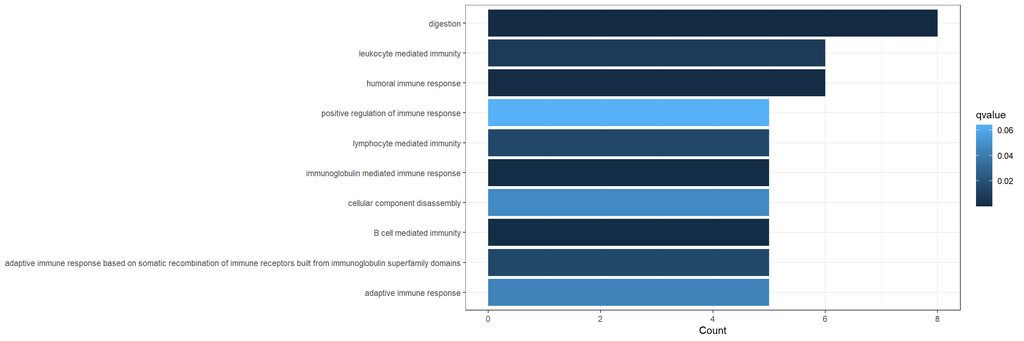

```r
# GO (upregulated)
data <- or_go_up@result %>% arrange(-Count)
data <- data[1:10,]

data %>% ggplot(aes(Count, reorder(Description,Count), fill = qvalue)) + geom_bar(stat='identity') + theme_bw() + theme(axis.title.y = element_blank())
```

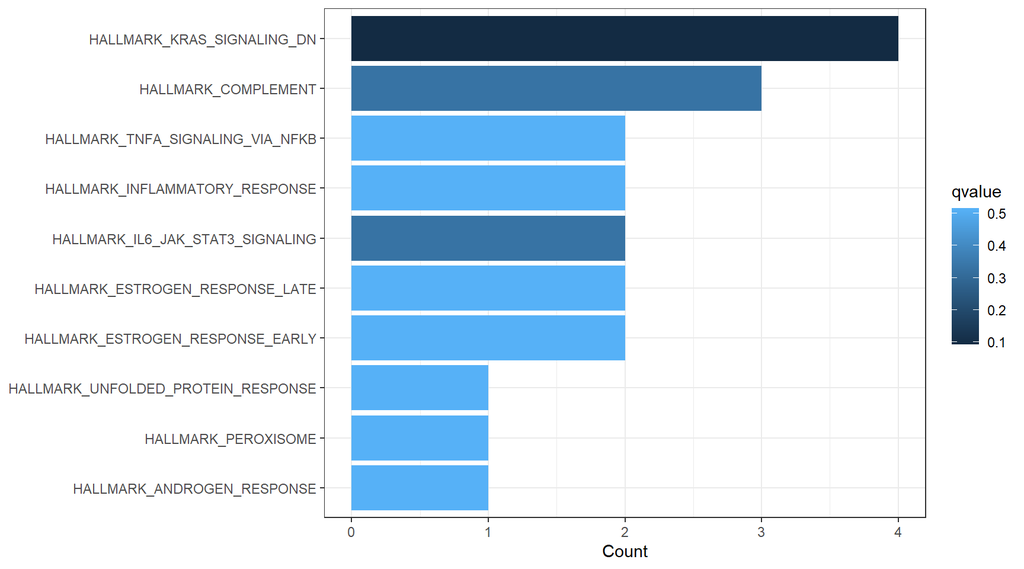

```r
# MSigDB Hallmark (upregulated)
data <- or_msigdb_h_up@result %>% arrange(-Count)
data <- data[1:10,]

data %>% ggplot(aes(Count, reorder(Description,Count), fill = qvalue)) + geom_bar(stat='identity') + theme_bw() + theme(axis.title.y = element_blank())
```

#### GSEA

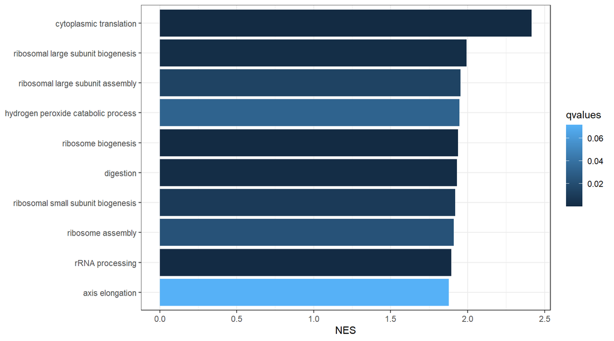

```r
# GO (upregulated)
data <- gsea_go@result %>% arrange(-NES)
data <- data[1:10,]

data %>% ggplot(aes(NES, reorder(Description,NES), fill = qvalues)) + geom_bar(stat='identity') + theme_bw() + theme(axis.title.y = element_blank())
```

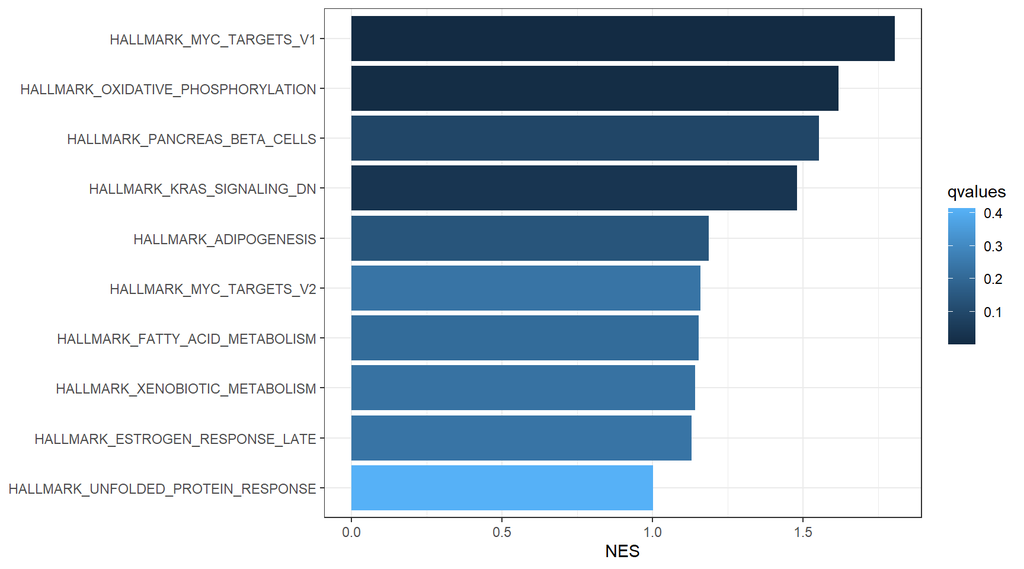

```r
# MSigDB Hallmark (upregulated)
data <- gsea_msigdb_h@result %>% arrange(-NES)
data <- data[1:10,]

data %>% ggplot(aes(NES, reorder(Description,NES), fill = qvalues)) + geom_bar(stat='identity') + theme_bw() + theme(axis.title.y = element_blank())
```

### Dot plot

#### ORA

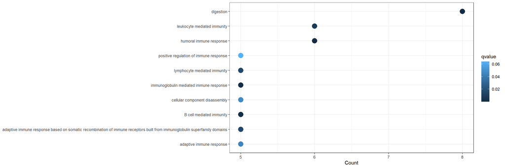

```r
# GO (upregulated)
data <- or_go_up@result %>% arrange(-Count)
data <- data[1:10,]

data %>% ggplot(aes(Count, reorder(Description, Count), color=qvalue, size=Count)) + geom_point(size = 5) + theme_bw() + theme(axis.title.y = element_blank())
```

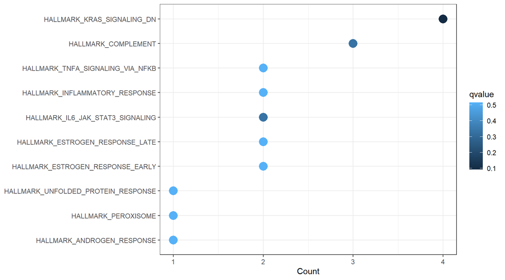

```r
# MSigDB Hallmark (upregulated)
data <- or_msigdb_h_up@result %>% arrange(-Count)
data <- data[1:10,]

data %>% ggplot(aes(Count, reorder(Description, Count), color=qvalue, size=Count)) + geom_point(size = 5) + theme_bw() + theme(axis.title.y = element_blank())
```

#### GSEA

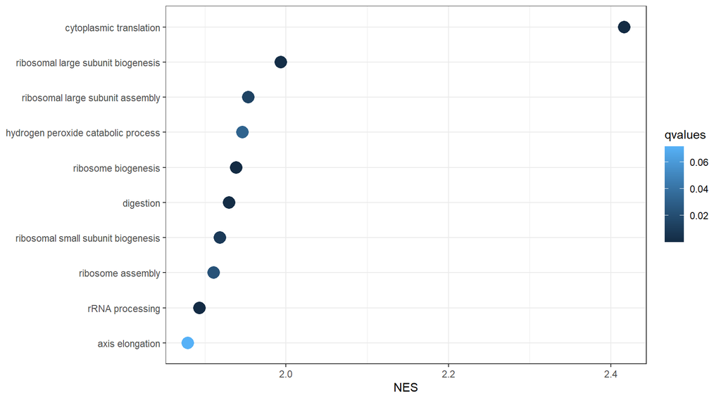

```r
# GO (upregulated)
data <- gsea_go@result %>% arrange(-NES)
data <- data[1:10,]

data %>% ggplot(aes(NES, reorder(Description, NES), color=qvalues, size=NES)) + geom_point(size = 5) + theme_bw() + theme(axis.title.y = element_blank())
```

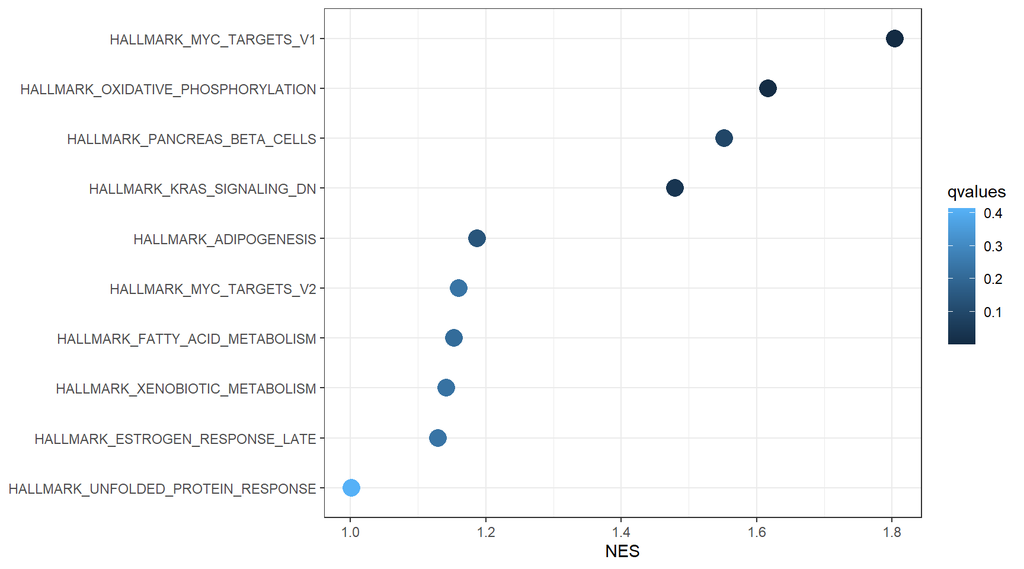

```r
# MSigDB Hallmark (upregulated)
data <- gsea_msigdb_h@result %>% arrange(-NES)
data <- data[1:10,]

data %>% ggplot(aes(NES, reorder(Description, NES), color=qvalues, size=NES)) + geom_point(size = 5) + theme_bw() + theme(axis.title.y = element_blank())
```